# Домашнее задание № 2

YASINOVSKY/OSTAPENKO

18 декабря 2016 г

# Загрузка и очистка данных

Загрузил данные в датафрейм data.

```r
data <- read.csv("../data/calif_penn_2011.csv");
```

Колличество строк

```r
nrow(data)
```

```
## [1] 11275
```

Колличество столбцов

```r
ncol(data)
```

```
## [1] 34
```

Производится поиск в каждом столбце na и их подсчет

```r
colSums(apply(data,c(1,2), is.na))
```

```
##                           X                     GEO.id2
##                           0                           0
##                     STATEFP                    COUNTYFP
##                           0                           0
##                     TRACTCE                  POPULATION
##                           0                           0
##                    LATITUDE                   LONGITUDE
##                           0                           0
##           GEO.display.label          Median_house_value
##                           0                         599
##                 Total_units                Vacant_units
##                           0                           0
##                Median_rooms  Mean_household_size_owners
##                         157                         215
## Mean_household_size_renters         Built_2005_or_later
##                         152                          98
##          Built_2000_to_2004                 Built_1990s
##                          98                          98
##                 Built_1980s                 Built_1970s
##                          98                          98
##                 Built_1960s                 Built_1950s
##                          98                          98
##                 Built_1940s       Built_1939_or_earlier
##                          98                          98
##                  Bedrooms_0                  Bedrooms_1
##                          98                          98
##                  Bedrooms_2                  Bedrooms_3
##                          98                          98
##                  Bedrooms_4          Bedrooms_5_or_more
##                          98                          98
##                      Owners                     Renters
##                         100                         100
##     Median_household_income       Mean_household_income
##                         115                         126
```

Колличество оставшихся строк, после удаления NA с помощью функции na.omit. Было удалено 670 строк.

```r
nrow(na.omit(data))
```

```
## [1] 10605
```

# Новые дома

Построена диаграмма рассеяния медианы стоимости домов относительно прцоента новых домов.

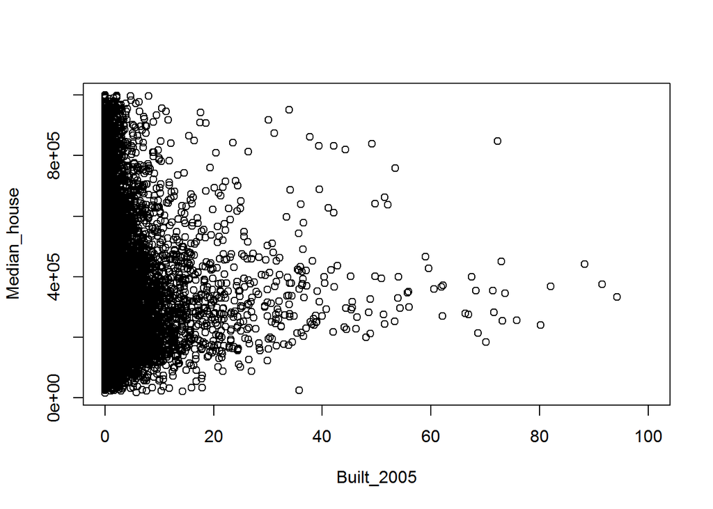

```r
Built_2005 = data[,'Built_2005_or_later']
Median_house = data[,'Median_house_value']
plot(Built_2005,Median_house)
```

Калифорния

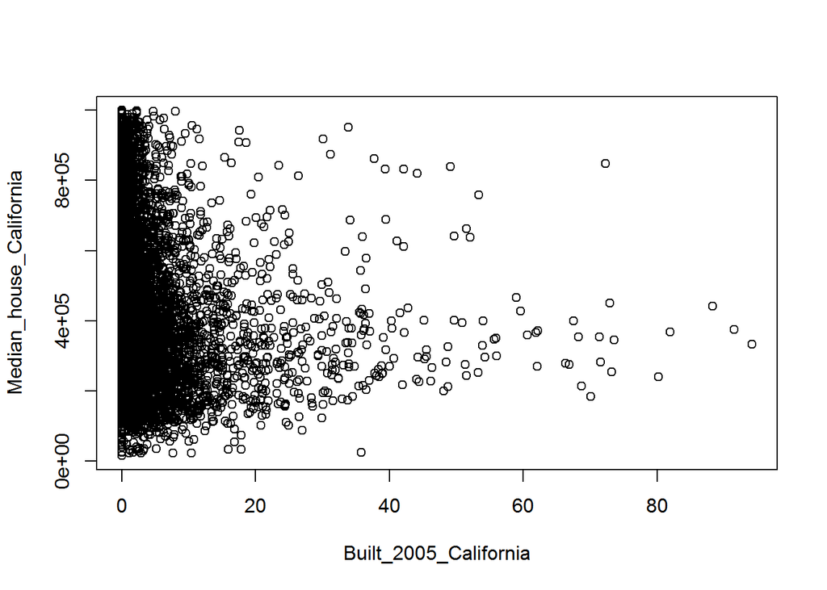

```r
Built_2005_California = data$Built_2005_or_later[data$STATEFP==6]
Median_house_California = data$Median_house_value[data$STATEFP==6]
plot(Built_2005_California,Median_house_California)
```

Пенсильвания

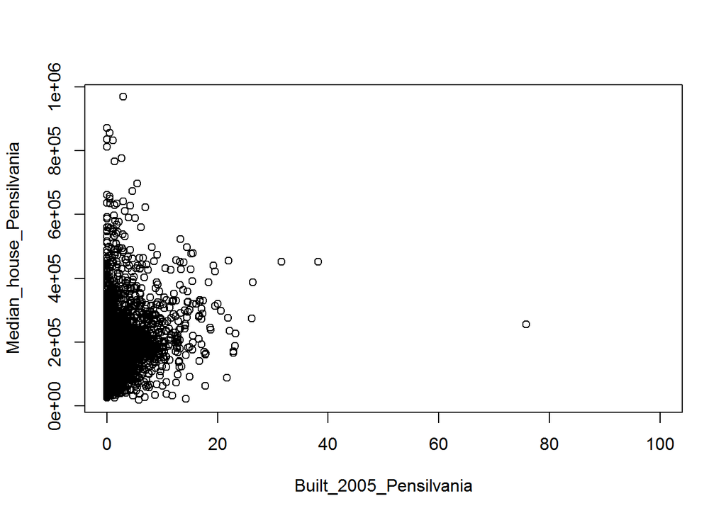

```r
Built_2005_Pensilvania = data$Built_2005_or_later[data$STATEFP==42]
Median_house_Pensilvania = data$Median_house_value[data$STATEFP==42]
plot(Built_2005_Pensilvania,Median_house_Pensilvania)
```

# Незанятые дома

В датафрейм daya добавил новую колонку vacancy_rate с выше описанным показателем.

```r
Total = data$Total_units
Vacant = data$Vacant_units
data$vacancy_rate = Vacant/Total
```

Нашел максимум, минимум, среднее значение и медиану.

```r
max(na.omit(data$vacancy_rate))
```

```
## [1] 1
```

```r
min(na.omit(data$vacancy_rate))
```

```
## [1] 0
```

```r
mean(na.omit(data$vacancy_rate))
```

```
## [1] 0.08917878
```

```r
median(na.omit(data$vacancy_rate))
```

```
## [1] 0.06766326
```

Построил диаграмму уровня найма относительно медаианы стоимости.

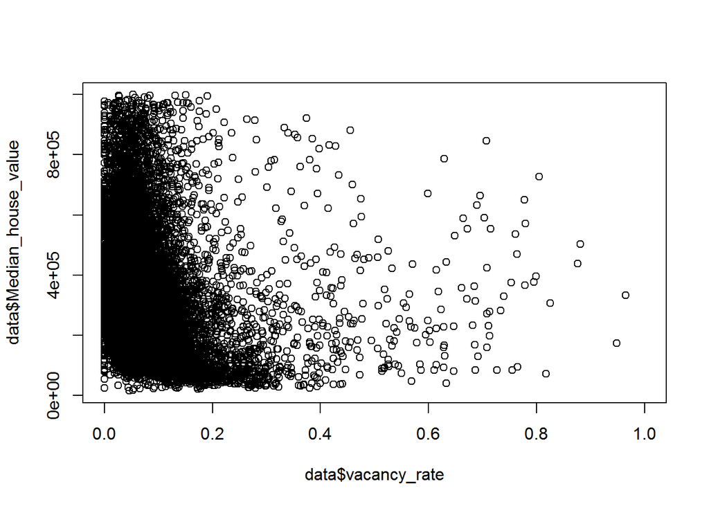

```r
plot(data$vacancy_rate, data$Median_house_value)
```

# Корреляция

Идет перебор по датафреймам. После чего идет выбор номера строки и добавление в вектор асс. Потом идет поиск медианы через функцию median().

```r
omit = na.omit(data)
acc <- c()
for (tract in 1:nrow(omit)) {
  if (omit$STATEFP[tract] == 6) {
    if (omit$COUNTYFP[tract] == 1) {
      acc <- c(acc, tract)
    }
  }
}
accmv <- c()
for (tract in acc) {
  accmv <- c(accmv, omit[tract,10])
}
median(accmv)
```

```
## [1] 474050
```

Тот же код.

```r
median(na.omit(data[which(data$STATEFP==6 & data$COUNTYFP==1),10]))
```

```
## [1] 473500
```

Средний процент построенных домовладений в округах (Butte County, Santa Clara, York County)

```r
mean(na.omit(data[which(data$STATEFP==6 & data$COUNTYFP==7),16]))
```

```
## [1] 4.703922
```

```r
mean(na.omit(data[which(data$STATEFP==6 & data$COUNTYFP==85),16]))
```

```
## [1] 3.160215
```

```r
mean(na.omit(data[which(data$STATEFP==42 & data$COUNTYFP==133),16]))
```

```
## [1] 4.421111
```

Расчет корреляции между медианой стоимости домовладений (Median_house_value) и процентом построенных домов (Built_2005_or_later):

1. Для всего набора данных

```r
cor(data$Median_house_value, data$Built_2005_or_later, use = "complete.obs")
```

```
## [1] -0.02052684
```

2. Для калифорнии

```r
na = na.omit(data)
cor(na[which(na$STATEFP==6),10], na[which(na$STATEFP==6),16], use = "complete.obs")
```

```
## [1] -0.1153604
```

3. Для Пенсильвании

```r
na = na.omit(data)
cor(na[which(na$STATEFP==42),10], na[which(na$STATEFP==42),16], use = "complete.obs")
```

```
## [1] 0.2681654
```

4. Для округа Butte Couunty

```r
na = na.omit(data)
BT = cor(na[which(na$STATEFP==6 & na$COUNTYFP==7),10], na[which(na$STATEFP==6 & na$COUNTYFP==7),16], use = "complete.obs")
BT
```

```
## [1] 0.04203267
```

5. Для округа Santa Clara

```r
na = na.omit(data)
cor(na[which(na$STATEFP==6 & na$COUNTYFP==85),10], na[which(na$STATEFP==6 & na$COUNTYFP==85),16], use = "complete.obs")
```

```
## [1] -0.1726203
```

6. Для округа York County

```r
na = na.omit(data)
cor(na[which(na$STATEFP==42 & na$COUNTYFP==133),10], na[which(na$STATEFP==42 & na$COUNTYFP==133),16], use = "complete.obs")
```

```
## [1] 0.3860773
```

Построил 3 диаграммы медианы стоимсоти домовлдений (Median_house_value) относительно медианы дохода (Median_household_income) для трёх округов.

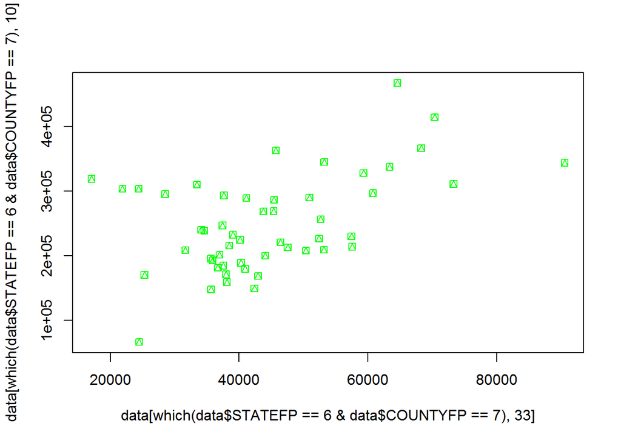

```r
plot(data[which(data$STATEFP==6 & data$COUNTYFP==7),33], data[which(data$STATEFP==6 & data$COUNTYFP==7),10],col="green",pch=14)
```

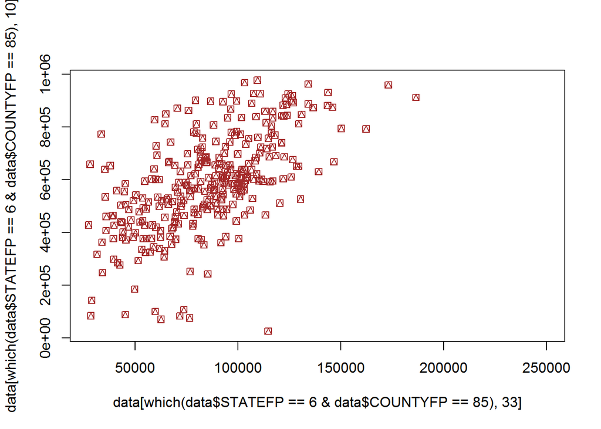

```r
plot(data[which(data$STATEFP==6 & data$COUNTYFP==85),33], data[which(data$STATEFP==6 & data$COUNTYFP==85),10],col="brown",pch=14)
```

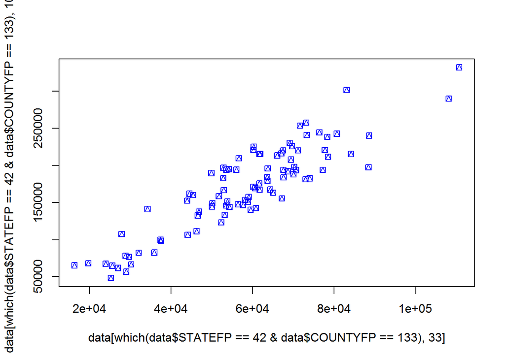

```r
plot(data[which(data$STATEFP==42 & data$COUNTYFP==133),33], data[which(data$STATEFP==42 & data$COUNTYFP==133),10],col="blue",pch=14)
```